# Data Checking - Dr. Guth Project

**Click to expand: Overall Table Summary Check Before Data Manipulation**

| **Characteristic** | **N = 199**<sup>1</sup> |
| --- | --- |
| ResearchID | 105,342 (103,730, 107,568) |
| AAC_clinical_grade |  |
| Fail | 0 (0%) |
| Pass | 5 (26%) |
| High Pass | 8 (42%) |
| Honors | 6 (32%) |
| Pass with remediation | 0 (0%) |
| Unknown | 180 |
| CPC_clinical_grade |  |
| Fail | 0 (0%) |
| Pass | 17 (13%) |
| High Pass | 45 (34%) |
| Honors | 71 (53%) |
| Pass with remediation | 0 (0%) |
| Unknown | 66 |
| HAC_clinical_grade |  |
| Fail | 0 (0%) |
| Pass | 41 (23%) |
| High Pass | 62 (35%) |
| Honors | 73 (41%) |
| Pass with remediation | 0 (0%) |
| Unknown | 23 |
| ICAC_clinical_grade |  |
| Fail | 0 (0%) |
| Pass | 40 (23%) |
| High Pass | 67 (39%) |
| Honors | 64 (37%) |
| Pass with remediation | 0 (0%) |
| Unknown | 28 |
| NC_clinical_grade |  |

[output cut: 267 more lines]

<sup>1</sup> Median (Q1, Q3); n (%)

Underrepresented in Medicine Variables- URM variable vs URM_AAMC : The URM variable provides higher overall representation of underrepresented in medicine students within the cohort compared to the stricter criteria (URM_AAMC). I suggest we use the URM variable in analysis for preventing small sample size limitations, maintaining adequate statistical power, and allowing for a more robust comparative evaluation.

```
## Non-URM     URM unknown
##     132      60       7
```

```
## Non-URiM     URiM  unknown
##      140       52        7
```

OSCE Variables-

OSCE: PI mentioned that they are most interested in the Communication and Physical examination OSCE exam scores, these will be treated as primary outcomes. OSCE scores were aggregated across component (communication, physical examination, medical documentation, or oral)

```
## # A tibble: 16 × 3
##    variable                       n_miss pct_miss
##    <fct>                           <int>    <dbl>
##  1 P1FallBodySys_PhysExamScore        46     23.1
##  2 P1SprBates_PhysExamScore           42     21.1
##  3 P1SprBates_CommScore               42     21.1
##  4 P1SprBates_MedDocScore             42     21.1
##  5 P2FallRamos_PhysExamScore          41     20.6
##  6 P2FallRamos_CommScore              41     20.6
##  7 P2FallRamos_OralPresScore          41     20.6
##  8 P2FallPayne_PhysExamScore          41     20.6
##  9 P2FallPayne_CommScore              41     20.6
## 10 P2FallPayne_MedDocScore            41     20.6
## 11 P2SpringHyde_PhysExamScore         42     21.1
## 12 P2SpringHyde_CommScore             42     21.1
## 13 P2SpringHyde_MedDocScore           42     21.1
## 14 P2SpringSnelling_PhysExamScore     42     21.1
## 15 P2SpringSnelling_CommScore         42     21.1
## 16 P2SpringSnelling_MedDocScore       65     32.7
```

This table above summarizes the missing data analysis, showing the count (n_miss) and percentage (pct_miss) of missing values for various OSCE component scores and exam metrics. Across the listed variables, missingness ranges from 41 to 65 observations, representing roughly 20.6% to 32.7% of the dataset.

```
## # A tibble: 8 × 3
##   n_osce_miss     n   pct
##         <dbl> <int> <dbl>
## 1           0   129  64.8
## 2           1    22  11.1
## 3           2     2   1
## 4           3     2   1
## 5           6     1   0.5
## 6           7     3   1.5
## 7          10     1   0.5
## 8          16    39  19.6
```

This table above evaluates missing OSCE scores at the student level, showing that the majority of students 129 students, or (64.8%) have complete data with zero missing scores. Across the remaining students, missing OSCE counts range from 1 to 16 missing items (16 missing items = all OSCE component scores).

After excluding 39 students who lacked complete OSCE data, the analytical sample for the new dataframe (df_clean) was reduced to a sample size of N = 160.

```
## # A tibble: 6 × 8
##   URM     URM_AAMC amcasEthnicityDesc amcas_othethnicity additional_ethnicity
##   <fct>   <fct>    <chr>              <lgl>              <chr>
## 1 unknown unknown  <NA>               NA                 Decline to Respond
## 2 unknown unknown  <NA>               NA                 Decline to Respond
## 3 unknown unknown  <NA>               NA                 Decline to Respond
## 4 unknown unknown  <NA>               NA                 Decline to Respond
## 5 unknown unknown  <NA>               NA                 Decline to Respond
## 6 unknown unknown  <NA>               NA                 Decline to Respond
## # ℹ 3 more variables: race_desc <chr>, race_cat_desc <chr>,
## #   additional_race <chr>
```

The above table confirms that 6 students actively declined to report their race/ethnicity on their applications, making it impossible to categorize their URM status and justifying their exclusion from the final analytical sample.

After excluding 6 students with unknown URM status, the final analytical sample comprised N = 154 students.

| **Characteristic** | **Overall** N = 154<sup>1</sup> | **Non-URM** N = 106<sup>1</sup> | **URM** N = 48<sup>1</sup> |
| --- | --- | --- | --- |
| gender |  |  |  |
| Male | 76 (49%) | 50 (47%) | 26 (54%) |
| Female | 78 (51%) | 56 (53%) | 22 (46%) |
| STEP1_ExamScore | 226.5 (20.8) | 229.5 (21.4) | 219.9 (17.8) |
| STEP2CK_ExamScore | 244.1 (13.7) | 246.7 (13.3) | 238.2 (12.9) |
| P1FallBodySys_PhysExamScore | 92.3 (5.4) | 93.0 (4.2) | 90.8 (7.4) |
| P1SprBates_PhysExamScore | 93.2 (6.5) | 93.4 (6.0) | 92.8 (7.5) |
| P1SprBates_CommScore | 91.5 (8.5) | 92.3 (8.1) | 89.7 (9.2) |
| P1SprBates_MedDocScore | 95.9 (7.3) | 96.7 (5.8) | 94.1 (9.6) |
| P2FallRamos_PhysExamScore | 94.8 (6.3) | 94.8 (6.9) | 94.7 (4.8) |
| P2FallRamos_CommScore | 94.7 (7.6) | 94.7 (7.7) | 94.7 (7.5) |
| P2FallRamos_OralPresScore | 96.9 (5.5) | 96.8 (5.8) | 97.1 (4.7) |
| P2FallPayne_PhysExamScore | 88.8 (6.3) | 88.8 (6.3) | 88.7 (6.4) |
| P2FallPayne_CommScore | 93.5 (7.9) | 93.3 (8.3) | 94.0 (6.8) |
| P2FallPayne_MedDocScore | 93.5 (7.3) | 94.4 (6.1) | 91.4 (9.2) |
| P2SpringHyde_PhysExamScore | 85.6 (9.7) | 87.2 (7.7) | 81.6 (12.4) |
| P2SpringHyde_CommScore | 90.2 (11.8) | 91.3 (11.0) | 87.6 (13.4) |
| P2SpringHyde_MedDocScore | 88.4 (10.0) | 88.7 (9.8) | 87.7 (10.5) |
| P2SpringSnelling_PhysExamScore | 85.2 (12.1) | 85.8 (11.4) | 83.8 (13.5) |
| P2SpringSnelling_CommScore | 92.5 (8.6) | 92.3 (8.9) | 93.1 (7.9) |
| P2SpringSnelling_MedDocScore | 89.6 (9.9) | 90.0 (10.4) | 88.5 (8.8) |

<sup>1</sup> Mean (SD); n (%)

Table 1 above: Baseline demographic characteristics, standardized examination scores (USMLE Step 1 and Step 2 CK), and OSCE performance metrics were summarized overall and stratified by URM status. Continuous variables are presented as mean (SD) and categorical variables as n (%).

Constructed OSCE variables represent the mean of the Bates, Ramos, Payne, Hyde, and Snelling scores for each evaluation component. For each student, available pre-clerkship OSCE scores were averaged across cases and semesters separately for communication, physical examination, medical documentation, and oral presentation.

**Click to expand: Mean Scores with SD by OSCE Exam - not aggregated**

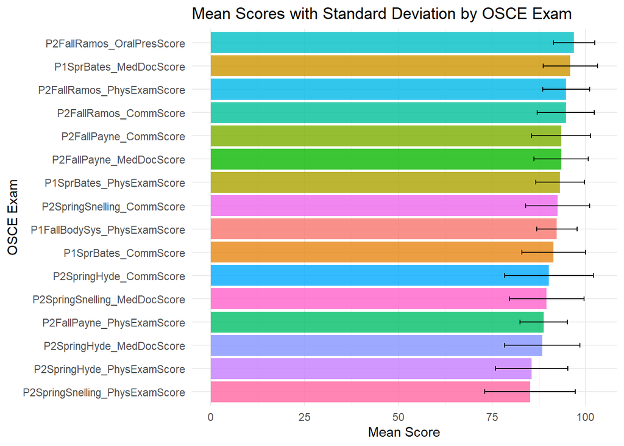

**Click to expand: Mean Scores with SD by OSCE Exam stratified by URM status - not aggregated**

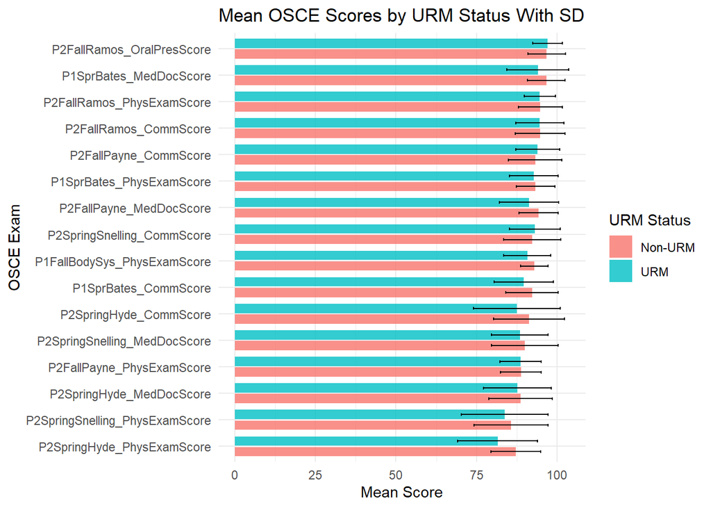

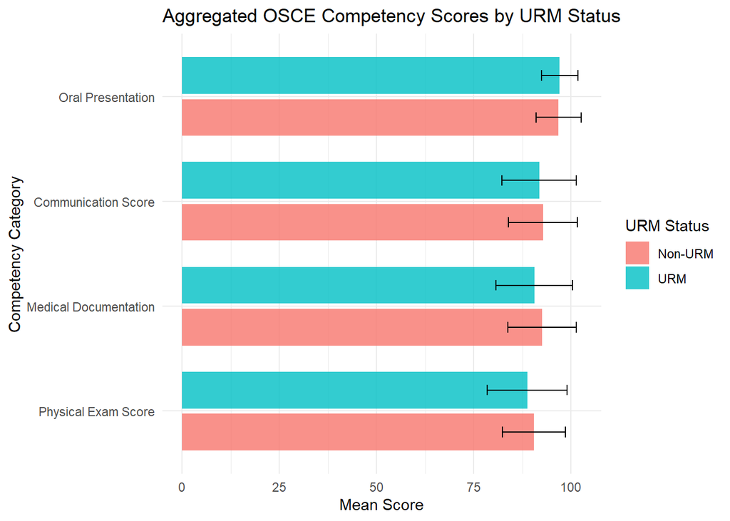

This grouped horizontal bar chart illustrates mean performance across the four aggregated OSCE competency categories (Oral Presentation, Communication, Medical Documentation, and Physical Examination), stratified by URM status. Mean scores and error bar spreads remain closely aligned between URM and non-URM groups across all four domains, with Oral Presentation showing the highest overall averages and Physical Examination recording slightly lower performance.

```
## # A tibble: 8 × 9
##   URM     Competency             Mean    SD Median   IQR   Min   Max N_students
##   <fct>   <chr>                 <dbl> <dbl>  <dbl> <dbl> <dbl> <dbl>      <int>
## 1 Non-URM Communication Score    92.8  8.90   95   10     50     100        154
## 2 URM     Communication Score    91.8  9.57   95   10.7   40     100        154
## 3 Non-URM Medical Documentation  92.5  8.81   95   10     47.5   100        154
## 4 URM     Medical Documentation  90.6  9.84   95   16.2   55     100        154
## 5 Non-URM Oral Presentation      96.8  5.82  100    5     70     100        154
## 6 URM     Oral Presentation      97.1  4.66  100    5     80     100        154
## 7 Non-URM Physical Exam Score    90.5  8.14   92.0  9.79  42.8   100        154
## 8 URM     Physical Exam Score    88.8 10.3    92.0 11.1   28.3   100        154
```

This summary table presents descriptive statistics (mean, standard deviation, median, IQR, min, max, and student count) for the four aggregated OSCE competency categories stratified by URM status. Overall performance metrics remain high and closely comparable across both URM and non-URM groups across all competency domains.

**Click to expand: OSCE Component Score Distributions by URM Status - aggregated**

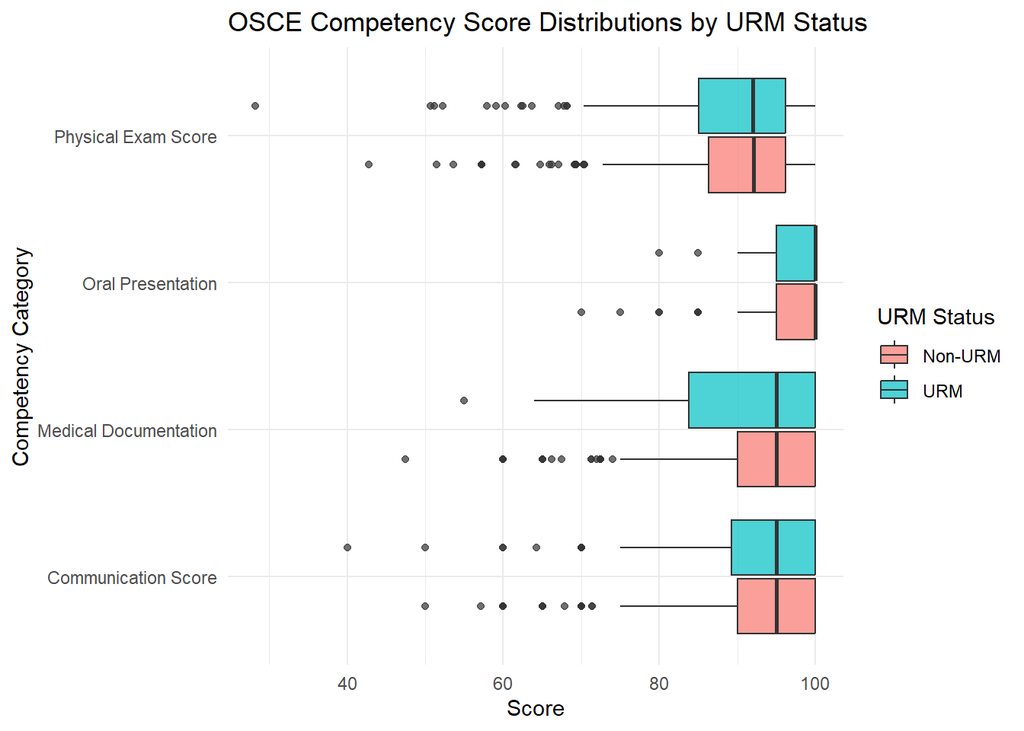

Final Clerkship Grades-

Final Clerkship grades: PI mentions wanting to focus on the final clerkship grades. There is a lot of missingness for some final clerkship grades (AAC, RCC) and others have only one option heavily preferred of ‘Pass’ (EC, MSK)

**Click to expand: Overall Table Summary For Final Clerkship Grades**

| **Characteristic** | **N = 154**<sup>1</sup> |
| --- | --- |
| AAC_Final_Course_Grade |  |
| Fail | 0 (0%) |
| Pass | 0 (0%) |
| High Pass | 1 (100%) |
| Honors | 0 (0%) |
| Pass with remediation | 0 (0%) |
| Unknown | 153 |
| CPC_Final_Course_Grade |  |
| Fail | 0 (0%) |
| Pass | 42 (33%) |
| High Pass | 38 (30%) |
| Honors | 48 (38%) |
| Pass with remediation | 0 (0%) |
| Unknown | 26 |
| EC_Final_Course_Grade |  |
| Fail | 0 (0%) |
| Pass | 154 (100%) |
| High Pass | 0 (0%) |
| Honors | 0 (0%) |
| Pass with remediation | 0 (0%) |
| HAC_Final_Course_Grade |  |
| Fail | 0 (0%) |
| Pass | 36 (26%) |
| High Pass | 50 (36%) |
| Honors | 51 (37%) |
| Pass with remediation | 0 (0%) |
| Unknown | 17 |
| ICAC_Final_Course_Grade |  |
| Fail | 0 (0%) |
| Pass | 31 (24%) |
| High Pass | 51 (39%) |
| Honors | 49 (37%) |
| Pass with remediation | 0 (0%) |
| Unknown | 23 |
| MSK_Final_Course_Grade |  |
| Fail | 1 (0.8%) |
| Pass | 121 (99%) |
| High Pass | 0 (0%) |
| Honors | 0 (0%) |
| Pass with remediation | 0 (0%) |
| Unknown | 32 |
| NC_Final_Course_Grade |  |
| Fail | 0 (0%) |
| Pass | 52 (35%) |
| High Pass | 43 (29%) |
| Honors | 52 (35%) |
| Pass with remediation | 0 (0%) |
| Unknown | 7 |
| OBG_Final_Course_Grade |  |
| Fail | 0 (0%) |
| Pass | 36 (27%) |
| High Pass | 44 (33%) |
| Honors | 51 (39%) |
| Pass with remediation | 1 (0.8%) |
| Unknown | 22 |
| OPC_Final_Course_Grade |  |
| Fail | 0 (0%) |
| Pass | 26 (19%) |
| High Pass | 50 (37%) |
| Honors | 60 (44%) |
| Pass with remediation | 0 (0%) |
| Unknown | 18 |
| PC_Final_Course_Grade |  |
| Fail | 0 (0%) |
| Pass | 41 (32%) |
| High Pass | 46 (35%) |
| Honors | 43 (33%) |
| Pass with remediation | 0 (0%) |
| Unknown | 24 |
| RCC_Final_Course_Grade |  |
| Fail | 0 (0%) |
| Pass | 1 (100%) |
| High Pass | 0 (0%) |
| Honors | 0 (0%) |
| Pass with remediation | 0 (0%) |
| Unknown | 153 |
| URM |  |
| Non-URM | 106 (69%) |
| URM | 48 (31%) |
| unknown | 0 (0%) |

<sup>1</sup> n (%)

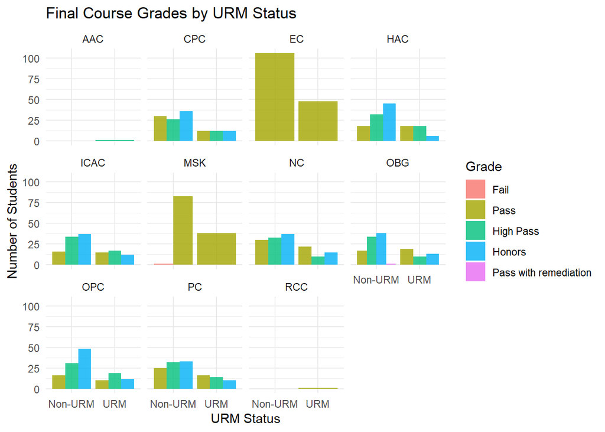

This faceted bar chart illustrates the distribution of final course grades across pre-clerkship courses, stratified by URM status. Across most courses, grade distributions consistently span Pass, High Pass, and Honors categories for both groups.

Clinical Clerkship Grades-

**Click to expand: Overall Table Summary For Clinical Clerkship Grades**

| **Characteristic** | **N = 154**<sup>1</sup> |
| --- | --- |
| AAC_clinical_grade |  |
| Fail | 0 (NA%) |
| Pass | 0 (NA%) |
| High Pass | 0 (NA%) |
| Honors | 0 (NA%) |
| Pass with remediation | 0 (NA%) |
| Unknown | 154 |
| CPC_clinical_grade |  |
| Fail | 0 (0%) |
| Pass | 12 (11%) |
| High Pass | 35 (32%) |
| Honors | 63 (57%) |
| Pass with remediation | 0 (0%) |
| Unknown | 44 |
| HAC_clinical_grade |  |
| Fail | 0 (0%) |
| Pass | 32 (24%) |
| High Pass | 45 (34%) |
| Honors | 57 (43%) |
| Pass with remediation | 0 (0%) |
| Unknown | 20 |
| ICAC_clinical_grade |  |
| Fail | 0 (0%) |
| Pass | 27 (21%) |
| High Pass | 53 (41%) |
| Honors | 50 (38%) |
| Pass with remediation | 0 (0%) |
| Unknown | 24 |
| NC_clinical_grade |  |
| Fail | 0 (0%) |
| Pass | 13 (11%) |
| High Pass | 61 (50%) |
| Honors | 47 (39%) |
| Pass with remediation | 0 (0%) |
| Unknown | 33 |
| OBG_clinical_grade |  |
| Fail | 0 (0%) |
| Pass | 29 (26%) |
| High Pass | 41 (36%) |
| Honors | 43 (38%) |
| Pass with remediation | 0 (0%) |
| Unknown | 41 |
| OPC_clinical_grade |  |
| Fail | 0 (0%) |
| Pass | 15 (13%) |
| High Pass | 51 (44%) |
| Honors | 51 (44%) |
| Pass with remediation | 0 (0%) |
| Unknown | 37 |
| PC_clinical_grade |  |
| Fail | 0 (0%) |
| Pass | 35 (32%) |
| High Pass | 38 (34%) |
| Honors | 38 (34%) |
| Pass with remediation | 0 (0%) |
| Unknown | 43 |
| RCC_clinical_grade |  |
| Fail | 0 (NA%) |
| Pass | 0 (NA%) |
| High Pass | 0 (NA%) |
| Honors | 0 (NA%) |
| Pass with remediation | 0 (NA%) |
| Unknown | 154 |
| URM |  |
| Non-URM | 106 (69%) |
| URM | 48 (31%) |
| unknown | 0 (0%) |

<sup>1</sup> n (%)

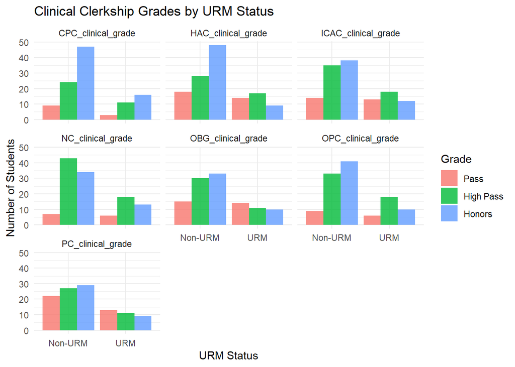

This faceted bar chart above illustrates the distribution of clinical clerkship grades across required specialty rotations, stratified by URM status. Across most clinical clerkships, grade distributions span Pass, High Pass, and Honors categories for both groups.

USMLE scores-

| **Characteristic** | **Overall** N = 154 | **Non-URM** N = 106 | **URM** N = 48 |
| --- | --- | --- | --- |
| USMLE Step 1 |  |  |  |
| Mean (SD) | 226.5 (20.8) | 229.5 (21.4) | 219.9 (17.8) |
| Median [Q1, Q3] | 227.5 [211.0, 244.0] | 232.0 [211.0, 247.0] | 220.5 [208.5, 229.0] |
| USMLE Step 2 CK |  |  |  |
| Mean (SD) | 244.1 (13.7) | 246.7 (13.3) | 238.2 (12.9) |
| Median [Q1, Q3] | 245.0 [235.0, 255.0] | 248.0 [237.0, 256.0] | 239.0 [229.0, 249.0] |
| Missing | 1 | 0 | 1 |

These scores visually don’t look like there is anything weird going on here - good!

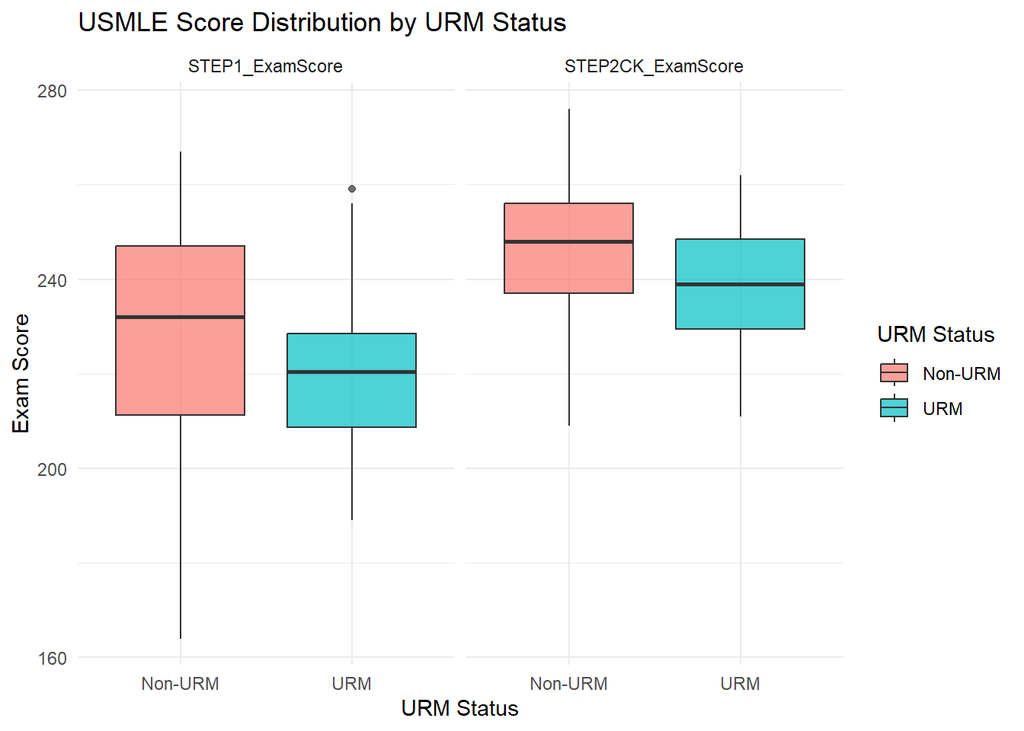

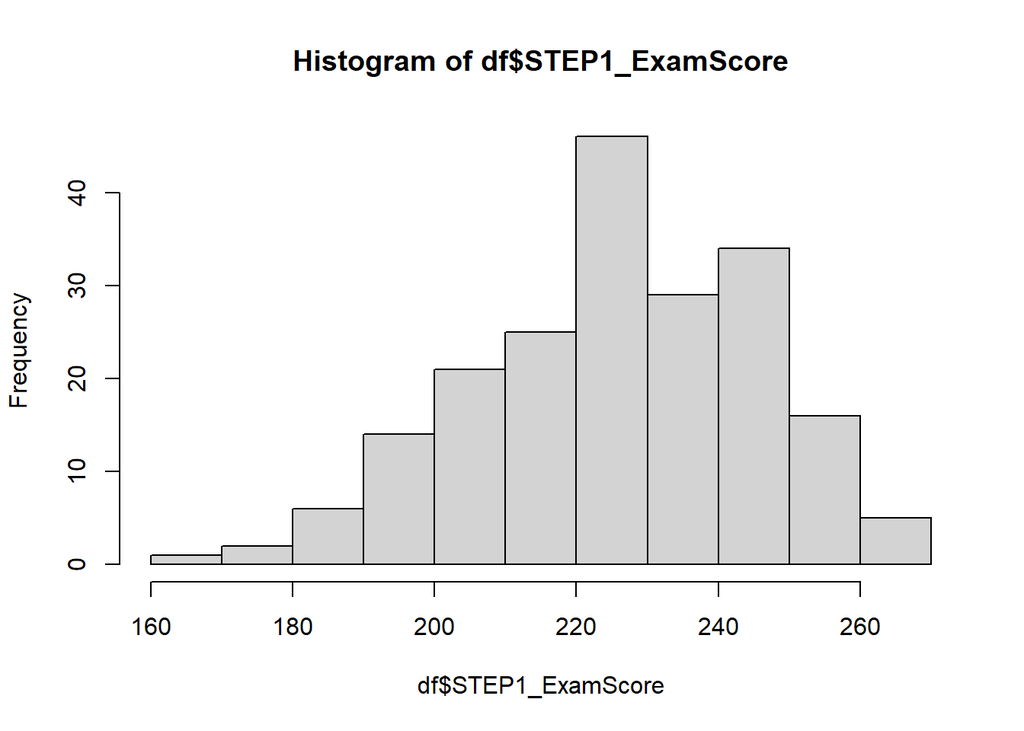

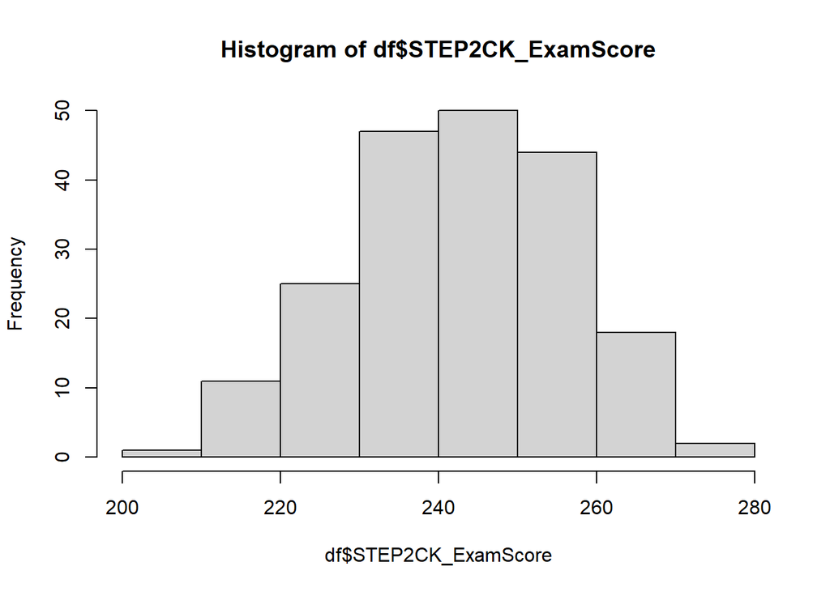

These histograms display the overall score distributions for USMLE Step 1 and Step 2 CK examinations across the student cohort. Both distributions approximate normal curves centered around their respective mean and median values without major skewness.

Future Analysis Preview-

Gender variable: The variable gender for this data set is pretty equal, there is one row that has that variable marked as ‘unknown’. N=198 with either male or female

```
##    Male  Female unknown
##      97     101       1
```